# Data Processing with R - part 2

John Pinney

January 2020

Here’s the code to rebuild the `countries`, `co2` and `stats97` tibbles, which we’ll be continuing to work with in this session:

```r
countries <- read_excel("data_geographies_v1.xlsx", sheet = "list-of-countries-etc")
```

```
-
/
```

```r
co2 <- read_csv("yearly_co2_emissions_1000_tonnes.csv")
co2 <- gather(co2, -c(country,geo), key=year, value=kt, na.rm=TRUE)
co2$year <- parse_integer(co2$year)
stats97 <- read_csv("1997_stats.csv", col_names=FALSE)
stats97 <- separate(stats97, col=X1, sep="-", into=c("geo","measurement"))
stats97 <- spread(stats97, key=measurement, value=X2)
```

# 1 Pipes

Often, the operations we want to apply to data require several steps. Because R is organised around functions, we can sometimes get tied up with nested parentheses `()`, or confused by a lot of intermediate variables.

One solution for more understandable code is to make use of **pipes** (from the [magrittr](https://magrittr.tidyverse.org/) package) to chain functions together.

The pipe operator is `%>%`.

We can think of `x %>% f` as having the same meaning as `f(x)`.

A simple example:

```r
1:10 %>% mean
```

```
[1] 5.5
```

We can also pipe the output to a new function:

```r
1:10 %>%
  mean %>%
  log
```

```
[1] 1.704748
```

To capture the result of a chain of pipes, use variable assignment with the arrow operator as normal:

```r
x <- 1:10 %>%
  mean %>%
  log
x
```

```
[1] 1.704748
```

By default, the piped value is used as the **first argument** of the function to which it is directed.

Any further **positional arguments** that are given to the function will be associated with the second argument onwards:

```r
1:10 %>%
  sample(5)  # sample(x, s) returns a random sample (without replacement) of size s from the vector x
```

```
[1] 5 6 1 7 3
```

However, for functions that take more than one argument, sometimes we need to refer to the piped value directly using `.`:

```r
1:10 %>%
  mean %>%
  log %>%
  rnorm(10, ., 1)  # rnorm(n, mu, sd) returns a vector of n random samples from a normal distribution with mean mu and standard deviation sd
```

```
 [1]  1.7584425  0.4465392  3.1895572  2.1808699  3.3283906 -0.5143054
 [7]  1.3381643  2.9872918  2.1544790  2.0386044
```

#### Exercise

To recap from the last session, this is how we made a histogram of per-capita CO2 emissions for 1997, starting with the `co2` and `stats97` tibbles:

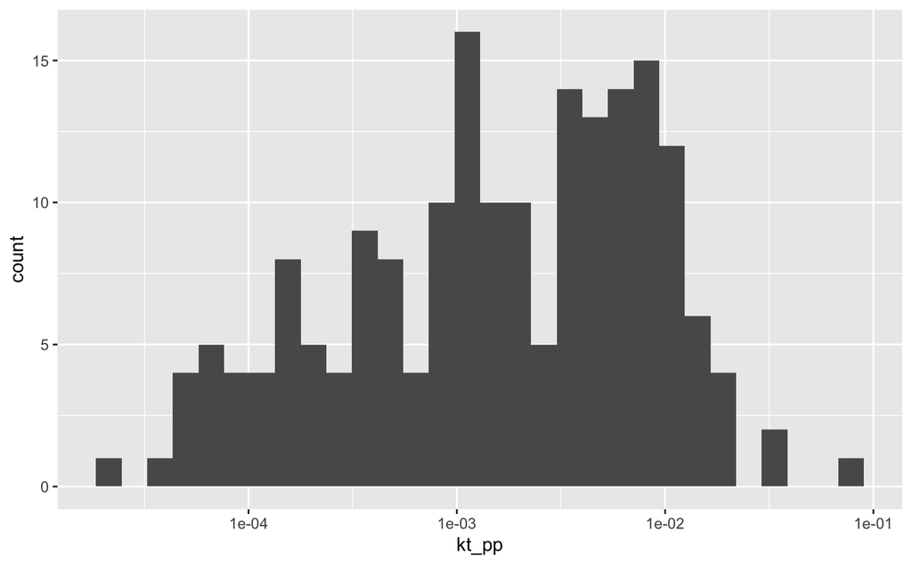

```r
co2_1997 <- filter(co2, year==1997)
co2_1997 <- left_join(co2_1997, stats97[,c("geo","pop")], by="geo")
co2_1997 <- mutate(co2_1997, kt_pp=kt/pop)
ggplot(co2_1997,aes(x=kt_pp)) +
  geom_histogram(bins=30) +
  scale_x_log10()
```

Can you rewrite the workflow above to use pipes instead of overwriting variables?

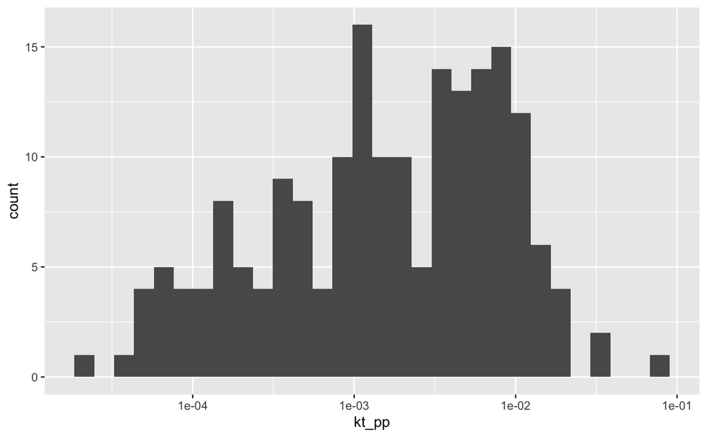

```r
co2 %>%
  filter(year==1997) %>%
  left_join(stats97[,c("geo","pop")], by="geo") %>%
  mutate(kt_pp=kt/pop) %>%
  ggplot(aes(x=kt_pp)) +
  geom_histogram(bins=30) +
  scale_x_log10()
```

#### Exercise

The file `population_total.csv` contains (real or predicted) population data for each country for the years 1800-2100.

Write a workflow to construct a tibble `co2_pp` containing the following columns:

- country
- geo
- year
- kt = total CO2 emissions (in kilotonnes)
- pop = total population
- t_pp = per-capita CO2 emissions (in tonnes)

```r
population <- read_csv("population_total.csv") %>%        # load the population data
  gather(-c(country,geo),                                 # tidy the data
         key=year,
         value=pop,
         na.rm=TRUE) %>%
  mutate(year=parse_integer(year))                        # convert strings to numbers
co2_pp <- co2 %>%
  left_join(population) %>%                               # join on (country, geo, year)
  drop_na(pop) %>%                                        # drop rows with no population data
  mutate(t_pp = 1000*kt/pop)                              # calculate per-capita emissions in tonnes
```

Plot the annual *per-capita* CO2 emissions of a country of your choice.

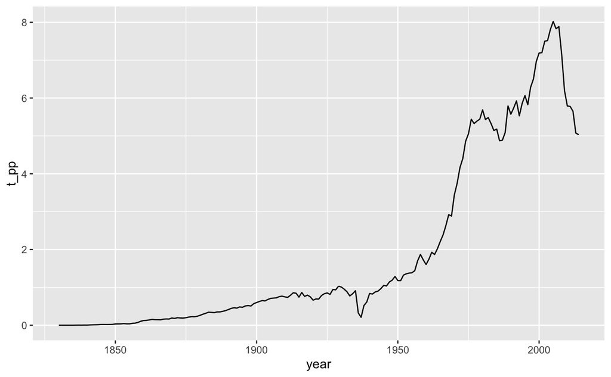

```r
co2_pp %>%
  filter(country=="Spain") %>%
  ggplot(aes(x=year,y=t_pp)) +
  geom_line()
```

# 2 Summarising data across groups

Cases often belong to distinct groups that we want to compare with each other in some way.

#### Exercise

Starting with the `co2_pp` tibble, add a column for the `eight_regions` grouping (taken from the `countries` tibble).

```r
geo_8 <- countries[c("geo","eight_regions")]  # get the columns
co2_pp <- left_join(co2_pp, geo_8, by="geo")    # join to co2_pp
head(co2_pp)
```

| country | geo | year | kt | pop | t_pp | eight_regions |
| --- | --- | --- | --- | --- | --- | --- |
| Canada | can | 1800 | 3.67 | 646000 | 0.005681115 | america_north |
| Germany | deu | 1800 | 796.00 | 22900000 | 0.034759825 | europe_west |
| Poland | pol | 1800 | 407.00 | 9510000 | 0.042797056 | europe_west |
| United Kingdom | gbr | 1800 | 26700.00 | 12300000 | 2.170731707 | europe_west |
| United States | usa | 1800 | 253.00 | 6800000 | 0.037205882 | america_north |
| Canada | can | 1801 | 3.67 | 653000 | 0.005620214 | america_north |

## 2.1 Box plots

Let’s look at the data for 2014 only. Here’s a more complex visualisation of the data, made by adjusting the data mappings in `aes()`:

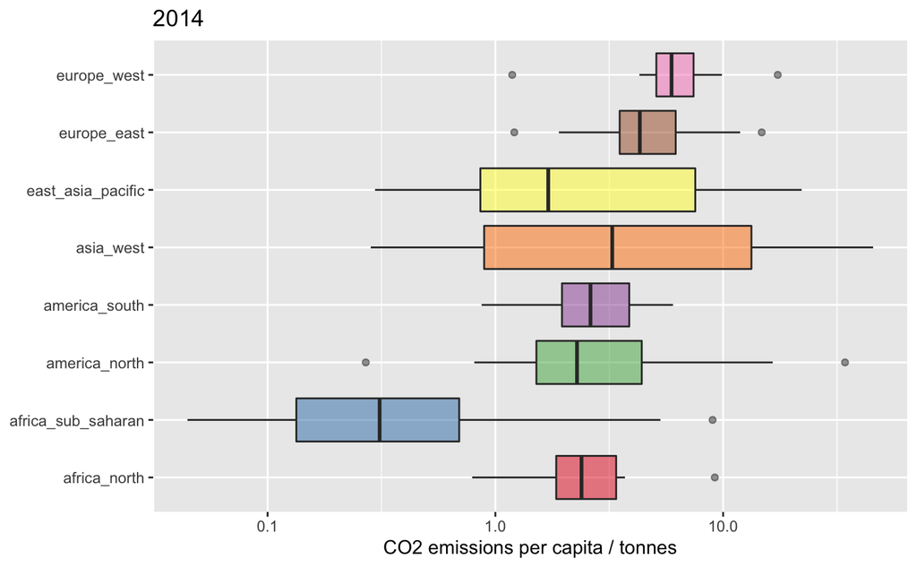

```r
co2_pp %>%
  filter(year==2014) %>%                                  # filter by year
  ggplot(aes(x=eight_regions,                             # map eight_regions to x-axis
             y=t_pp,                                      # map t_pp to y-axis
             fill=eight_regions)) +                       # map eight_regions to fill colour
    geom_boxplot(alpha=0.5) +                             # make boxplots
    scale_fill_brewer(palette="Set1") +                   # choose the colour palette
    labs(x=NULL,                                          # remove the x-axis label
         y="CO2 emissions per capita / tonnes",           # change the y-axis label
         title="2014") +                                  # add a title
    guides(fill="none") +                                 # remove the legend
    scale_y_log10() +                                     # use a log scale
    coord_flip()                                          # transpose the coordinates x <-> y
```

```r
NA
```

## 2.2 group_by() and summarise()

Let’s extract the corresponding summary statistics for each group:

```r
co2_pp %>%
  filter(year==2014) %>%
  group_by(eight_regions) %>%
  summarise(min=min(t_pp),
            q25=quantile(t_pp,0.25),
            median=median(t_pp),
            q75=quantile(t_pp,0.75),
            max=max(t_pp)) %>%
  arrange(desc(median))
```

| eight_regions | min | q25 | median | q75 | max |
| --- | --- | --- | --- | --- | --- |
| europe_west | 1.18598383 | 5.0915849 | 5.937240 | 7.418219 | 17.374101 |
| europe_east | 1.21130221 | 3.5143312 | 4.307932 | 6.192303 | 14.772727 |
| asia_west | 0.28374558 | 0.8928385 | 3.259804 | 13.337999 | 45.569620 |
| america_south | 0.87022901 | 1.9613952 | 2.616189 | 3.896836 | 6.026059 |
| africa_north | 0.79166667 | 1.8598757 | 2.397515 | 3.429979 | 9.193548 |
| america_north | 0.26981132 | 1.5182511 | 2.283019 | 4.394654 | 34.296296 |
| east_asia_pacific | 0.29635258 | 0.8631183 | 1.709476 | 7.547266 | 22.111650 |
| africa_sub_saharan | 0.04448938 | 0.1337225 | 0.310398 | 0.695421 | 8.990826 |

`dplyr` provides the `group_by()` function to create a “grouped” version of the tibble. Manipulations on the grouped data will be applied to each group separately and then combined.

Here, the function `summarise()` is used to make new variables for the summary statistics. The resulting tibble has one row for each of the groups.

#### Exercise

Plot the total global CO2 emissions for each year. *Hint*: Start with `co2_pp` and use `group_by()` and `summarise()`.

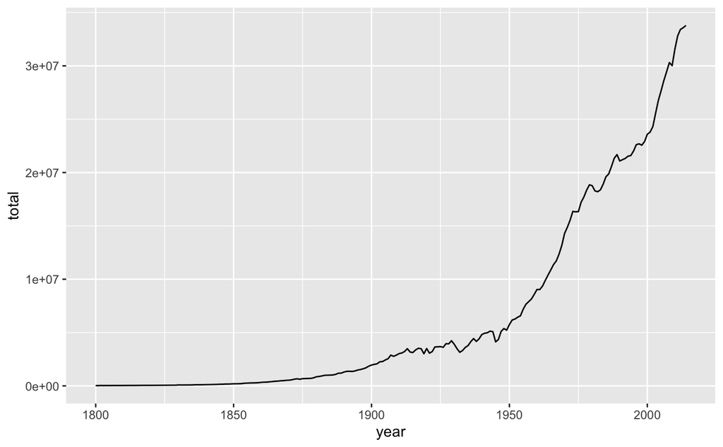

```r
co2_pp %>%
  group_by(year) %>%
  summarise(total=sum(kt)) %>%
  ggplot(aes(x=year,y=total)) +
  geom_line()
```

`group_by()` is a particularly powerful feature, because it allows you to group by more than one variable at a time. For example:

```r
co2_pp %>%
  group_by(eight_regions, year) %>%
  summarise(total_pop=sum(pop))
```

| eight_regions | year | total_pop |
| --- | --- | --- |
| africa_north | 1911 | 11400000 |
| africa_north | 1912 | 11500000 |
| africa_north | 1913 | 11700000 |
| africa_north | 1914 | 11900000 |
| africa_north | 1915 | 12000000 |
| africa_north | 1916 | 19980000 |
| africa_north | 1917 | 20290000 |
| africa_north | 1918 | 20590000 |
| africa_north | 1919 | 18790000 |
| africa_north | 1920 | 21210000 |

[output cut: 990 more lines]

#### Exercise

Plot the yearly per-capita CO2 emissions for the eight regions.

*Hint*: to map a variable (e.g. `xx`) to line colour, use `aes(color=xx)`.

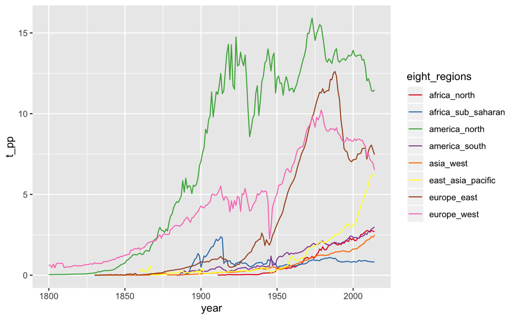

```r
co2_pp %>%
  group_by(eight_regions, year) %>%
  summarise(total_kt=sum(kt),total_pop=sum(pop)) %>%
  mutate(t_pp=1000*total_kt/total_pop) %>%
  ggplot(aes(x=year, y=t_pp, color=eight_regions)) +
    geom_line() +
    scale_color_brewer(palette="Set1")
```

## 2.3 Facets

Instead of plotting everything on the same axes, sometimes it is clearer to make a small panel for each plot (known as a *small multiple*). This is done using the `facet_wrap` function:

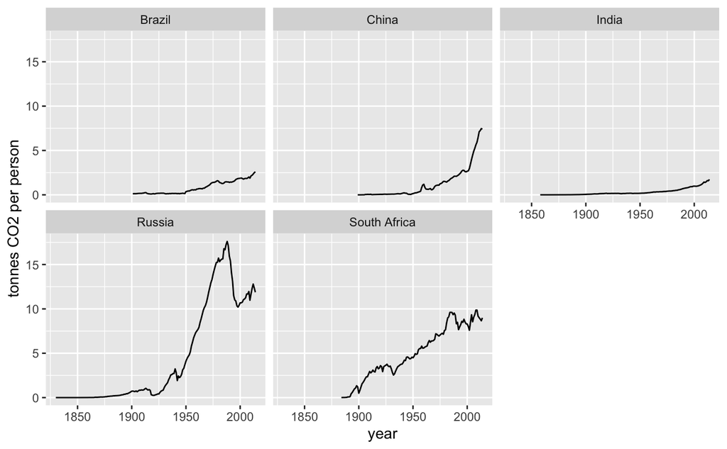

```r
co2_pp %>%
  filter(country %in% c("Brazil","Russia","India","China","South Africa")) %>%
  ggplot(aes(x=year, y=t_pp)) +
  geom_line() +
  facet_wrap(vars(country)) +
  labs(y="tonnes CO2 per person")
```

#### Exercise

Try applying `facet_wrap()` to the eight regions plot you made in the previous exercise.

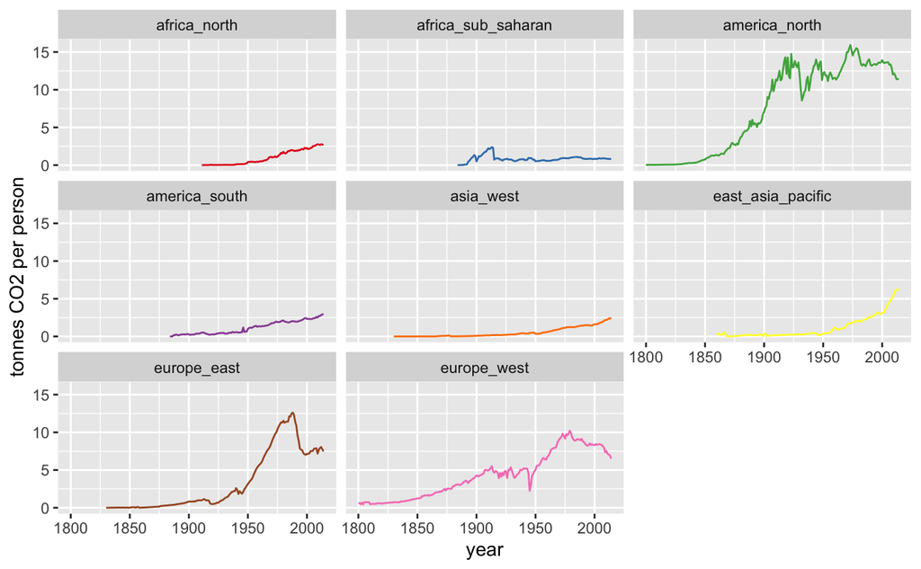

```r
co2_pp %>%
  group_by(eight_regions, year) %>%
  summarise(total_kt=sum(kt),total_pop=sum(pop)) %>%
  mutate(t_pp=1000*total_kt/total_pop) %>%
  ggplot(aes(x=year, y=t_pp, color=eight_regions)) +
    geom_line() +
    scale_color_brewer(palette="Set1") +
    facet_wrap(vars(eight_regions)) +
    guides(colour="none") +
    labs(y="tonnes CO2 per person")
```

# 3 Statistical testing

The Kyoto protocol committing states to reduce greenhouse gas emissions was signed in December 1997. Between then and 2014, is there any evidence that countries are making effort to reduce CO2 output?

To begin, let’s consider the per capita CO2 emissions for the `europe_west` countries in 1997 and 2014:

```r
co2_pp %>%
  filter(eight_regions=="europe_west", year %in% c(1997,2014)) %>%
  group_by(year) %>%
  summarise(mean=mean(t_pp), sd=sd(t_pp))
```

| year | mean | sd |
| --- | --- | --- |
| 1997 | 8.573134 | 3.072455 |
| 2014 | 6.617832 | 3.085314 |

So there is a reduction in the mean, but also a substantial variation between countries in both years.

Let’s compare the distributions visually with violin plots:

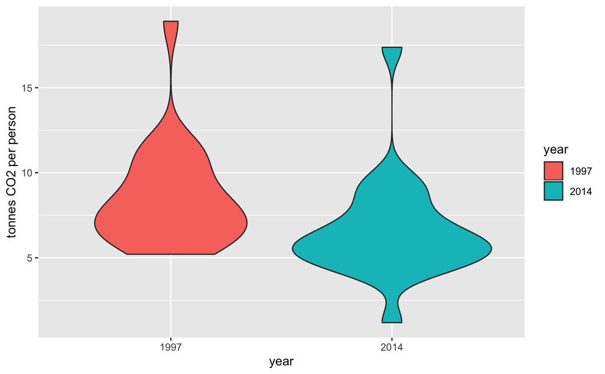

```r
co2_pp %>%
  filter(eight_regions=="europe_west",      # filter by eight_regions
         year %in% c(1997,2014)) %>%        # filter by year
  mutate(year=factor(year)) %>%             # convert year to a factor for grouping
  ggplot(aes(x=year,y=t_pp, fill=year)) +   # map year to fill colour
  geom_violin() +                           # make violin plots
  labs(y="tonnes CO2 per person")
```

A reduction looks plausible, but is there a statistically significant change in the mean?

Because the data are positively skewed, let’s work with `log10(t_pp)` to get closer to a normal distribution:

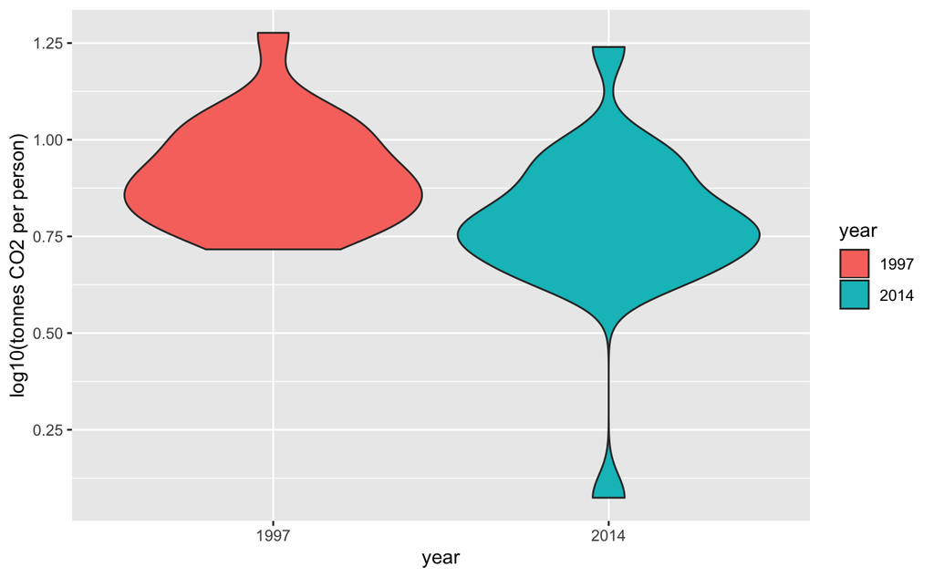

```r
co2_pp %>%
  filter(eight_regions=="europe_west",
         year %in% c(1997,2014)) %>%
  mutate(year=factor(year)) %>%
  ggplot(aes(x=year, y=log10(t_pp), fill=year)) +                         # now using log10(t_pp)
  geom_violin() +
  labs(y="log10(tonnes CO2 per person)")
```

We will use a **paired sample t-test** to test the hypothesis

*H1*: The mean change in `log10(t_pp)` from 1997 to 2014 is negative.

against the null hypothesis

*H0*: The mean change in `log10(t_pp)` from 1997 to 2014 is zero or positive.

This hypothesis test is one-tailed, because we are only looking at evidence for a reduction in emissions.

We use the *paired* version of the t-test because an individual country’s value in 2014 clearly depends on its value in 1997.

We will use a significance level of 5%.

First we construct a tibble with columns for the data vectors that we need for the test:

```r
dat <- co2_pp %>%
  filter(eight_regions=="europe_west",         # filter by eight_regions
         year %in% c(1997,2014)) %>%           # filter by year
  select(country,year,t_pp) %>%                # only using these variables
  spread(year,t_pp) %>%                        # reshape the data
  drop_na()                                    # drop rows with missing data
dat
```

| country | 1997 | 2014 |
| --- | --- | --- |
| Andorra | 7.247278 | 5.833333 |
| Austria | 7.808219 | 6.801854 |
| Belgium | 11.274510 | 8.339286 |
| Cyprus | 6.576880 | 5.269565 |
| Denmark | 11.666667 | 5.918728 |
| France | 5.986395 | 4.719626 |
| Germany | 10.576687 | 8.834356 |
| Greece | 7.609091 | 5.955752 |
| Iceland | 7.692308 | 6.036585 |
| Ireland | 9.811321 | 7.270789 |

[output cut: 11 more lines]

Note that this is no longer a tidy tibble, but that’s OK - we are just using it as an intermediate step towards the test.

Next we use the `t.test()` function to obtain a p-value.

For paired samples, it is important that the vectors are of the same length and in the same order. This has already been ensured because:

1. the data are taken from a tibble containing the country names, so the values for 1997 and 2014 (taken from the tibble columns) are ordered in the same way.
2. we have used drop_na() to remove any rows with a missing value.

```r
res <- t.test(dat[["2014"]], dat[["1997"]],
              paired=TRUE,
              alternative = "less")          # i.e. H1: 2014 < 1997
print(res$p.value)
```

```
[1] 1.634044e-06
```

So p < 0.05 and hence there is substantial evidence to reject H0 for this group of countries.

#### Exercise

Which countries in `europe_west` made the biggest per-capita reductions in CO2 emissions 1997-2014? *Hint*: Start with the reshaped tibble (`dat`) made above.

```r
##### SOLUTION
dat %>%
  mutate(change=dat[["2014"]]-dat[["1997"]]) %>%
  arrange(change)
```

| country | 1997 | 2014 | change |
| --- | --- | --- | --- |
| Denmark | 11.666667 | 5.918728 | -5.7479388 |
| Belgium | 11.274510 | 8.339286 | -2.9352241 |
| United Kingdom | 9.039451 | 6.461538 | -2.5779127 |
| Ireland | 9.811321 | 7.270789 | -2.5405318 |
| Italy | 7.517483 | 5.369128 | -2.1483550 |
| Germany | 10.576687 | 8.834356 | -1.7423313 |
| Iceland | 7.692308 | 6.036585 | -1.6557223 |
| Greece | 7.609091 | 5.955752 | -1.6533387 |
| Poland | 9.090909 | 7.467363 | -1.6235462 |
| Switzerland | 5.853315 | 4.289186 | -1.5641286 |

[output cut: 11 more lines]

# 4 Iteration

How can we repeat the t-test for the other groups?

Firstly, we need to get hold of the group names as a vector:

```r
# convert column to a factor to extract the levels
groups <- levels(factor(co2_pp$eight_regions))
groups
```

```
[1] "africa_north"       "africa_sub_saharan" "america_north"      "america_south"
[5] "asia_west"          "east_asia_pacific"  "europe_east"        "europe_west"
```

## 4.1 for()

One solution would be to adapt the earlier code into a `for()` loop:

```r
for(g in groups) {

  dat <- co2_pp %>%
    filter(eight_regions==g,                     # filter by eight_regions
         year %in% c(1997,2014)) %>%
    select(country,year,t_pp) %>%
    spread(year,t_pp) %>%
    drop_na()
  res <- t.test(dat[["2014"]], dat[["1997"]],
              paired=TRUE,
              alternative = "less")
  print( str_c(g, ":  p =", res$p.value) )       # str_c() concatenates strings

}
```

```
[1] "africa_north:  p =0.999559227072308"
[1] "africa_sub_saharan:  p =0.982843848654168"
[1] "america_north:  p =0.869394149030891"
[1] "america_south:  p =0.988422919341269"
[1] "asia_west:  p =0.574257095673869"
[1] "east_asia_pacific:  p =0.785473484507712"
[1] "europe_east:  p =0.277596780928962"
[1] "europe_west:  p =1.63404425150583e-06"
```

This is fine if we only need to *look at* the p-values, but things will get complicated if we want to collect them as a vector (for example, in order to correct for multiple hypothesis testing).

## 4.2 map()

A more elegant solution would be to use one of the `map()` functions from the `purrr` package.

`map(x, f)` takes a list (or vector) x and a function f, and passes each element of x to f in turn. The output of `map()` is a list (the same length as x) containing the individual outputs of f:

```r
f <- function(x) {
  return(x + 100)
}
map(1:5, f)
```

```
[[1]]
[1] 101

[[2]]
[1] 102

[[3]]
[1] 103

[[4]]
[1] 104

[[5]]
[1] 105
```

Equivalently, using an **anonymous function**:

```r
map(1:5, function(x) return(x + 100))
```

```
[[1]]
[1] 101

[[2]]
[1] 102

[[3]]
[1] 103

[[4]]
[1] 104

[[5]]
[1] 105
```

`map()` also supports shortcuts in the form of **equations**, which can allow more compact code:

```r
map(1:5, ~ .x + 100)
```

```
[[1]]
[1] 101

[[2]]
[1] 102

[[3]]
[1] 103

[[4]]
[1] 104

[[5]]
[1] 105
```

For convenience and code optimisation, there are versions of `map()` that return vectors instead of lists. For example, `map_dbl()` returns a vector of numbers:

```r
map_dbl(1:5, ~ .x + 100)
```

```
[1] 101 102 103 104 105
```

We can use `map_dbl()` to produce a vector of p-values:

```r
do_t_test <- function(g) {                     # our function to do one test

  dat <- co2_pp %>%
    filter(eight_regions==g,                   # filter by eight_regions
         year %in% c(1997,2014)) %>%
    select(country,year,t_pp) %>%
    spread(year,t_pp) %>%
    drop_na()
  res <- t.test(dat[["1997"]], dat[["2014"]],
              paired=TRUE,
              alternative = "greater")
  return(res$p.value)                          # function returns the p-value

}
pvals <- map_dbl(groups, do_t_test)    # map group names to the t-test function
names(pvals) <- groups                 # add the group names to the vector
pvals
```

```
      africa_north africa_sub_saharan      america_north      america_south          asia_west
      9.995592e-01       9.828438e-01       8.693941e-01       9.884229e-01       5.742571e-01
 east_asia_pacific        europe_east        europe_west
      7.854735e-01       2.775968e-01       1.634044e-06
```

We can now apply a simple correction for the multiple hypothesis tests:

```r
pvals_corrected <- pvals * length(pvals)
pvals_corrected
```

```
      africa_north africa_sub_saharan      america_north      america_south          asia_west
      7.996474e+00       7.862751e+00       6.955153e+00       7.907383e+00       4.594057e+00
 east_asia_pacific        europe_east        europe_west
      6.283788e+00       2.220774e+00       1.307235e-05
```

The `map()` functions are generally faster and more useful than an equivalent `for()` loop, and they are much easier to understand than the equivalent `apply` functions from base R.

## 4.3 walk()

`walk(x, f)` acts in the same way as `map()`, but returns the input list `x`.

This is a suitable alternative to `map()` when there is no output to be collected from f - for example, if we are using it to print something to screen or write some data to a file.

#### Exercise

Use `walk()` to make a version of the violin plot for each of the eight regions, and save each one as a PNG image.

```r
##### SOLUTION
makefig <- function(g){
  co2_pp %>%
    filter(eight_regions==g, year %in% c(1997,2014)) %>%
    mutate(year=factor(year)) %>%
    ggplot(aes(x=year,y=log(t_pp), fill=year)) +
    geom_violin() +
    labs(y="log10(tonnes CO2 per person)")
  ggsave(str_c(g,".png"))
}
walk(groups, makefig)
```

# Further Reading

## Textbooks

These online textbooks cover a wide range of topics in R data processing using the tidyverse.

- Grolemung G & Wickham H, [R for Data Science](https://r4ds.had.co.nz/) (2017)
- Wickham H, [ggplot2: Elegant Graphics for Data Analysis](https://ggplot2-book.org) (2020)
- Chang W, [R Graphics Cookbook](https://r-graphics.org) (2019)
- Ismay C & Kim AY, [Statistical Inference via Data Science](https://moderndive.com) (2019)
- Sanchez G, [Handling Strings with R](https://www.gastonsanchez.com/r4strings/) (2016)

## Other web resources

The [RStudio cheat sheets](https://rstudio.com/resources/cheatsheets/) are great for a quick overview of the tidyverse functions.

The [tidyverse overview](https://tidyverse.tidyverse.org) provides links to further information on each individual package.

The RStudio team also provide some suggested [learning paths](https://education.rstudio.com/learn/) for beginner, intermediate and expert R users.

# Acknowledgements

All data used in this workshop are taken from https://www.gapminder.org/data/